# Practice 5.

## Objectives:

1. Understand the projection methods for classification.
2. Understand the Fisher discriminant.
3. Do a simple exploratory data analysis
4. Learn the **data cleaning and visualitzation** features of Pandas.

## Aplication:

Data basse: Data set from the UCI Machine Learning Repository (http://archive.ics.uci.edu/ml)

Database: Wine quality, http://archive.ics.uci.edu/ml/datasets/Wine+Quality

- Predict **quality** (score between 0 and 10)

```python
import pandas as pd
import os
import matplotlib.pyplot as plt
import numpy as np
import sklearn
from sklearn.discriminant_analysis import LinearDiscriminantAnalysis
from sklearn.preprocessing import StandardScaler
from sklearn.metrics import accuracy_score
from sklearn.metrics import confusion_matrix
from sklearn.metrics import ConfusionMatrixDisplay
```

```python
File = "winequality-red.csv"
Filename = os.path.join(os.getcwd(),'Data',File)
print(f'Filename with path: \n {Filename}')
Data = pd.read_csv(Filename)
Data.head().T
```

```
Filename with path:
 c:\mlearn-lab\FifthPractice\Data\winequality-red.csv
```

|  | 0 | 1 | 2 | 3 | 4 |
| --- | --- | --- | --- | --- | --- |
| fixed acidity | 7.4000 | 7.8000 | 7.800 | 11.200 | 7.4000 |
| volatile acidity | 0.7000 | 0.8800 | 0.760 | 0.280 | 0.7000 |
| citric acid | 0.0000 | 0.0000 | 0.040 | 0.560 | 0.0000 |
| residual sugar | 1.9000 | 2.6000 | 2.300 | 1.900 | 1.9000 |
| chlorides | 0.0760 | 0.0980 | 0.092 | 0.075 | 0.0760 |
| free sulfur dioxide | 11.0000 | 25.0000 | 15.000 | 17.000 | 11.0000 |
| total sulfur dioxide | 34.0000 | 67.0000 | 54.000 | 60.000 | 34.0000 |
| density | 0.9978 | 0.9968 | 0.997 | 0.998 | 0.9978 |
| pH | 3.5100 | 3.2000 | 3.260 | 3.160 | 3.5100 |
| sulphates | 0.5600 | 0.6800 | 0.650 | 0.580 | 0.5600 |
| alcohol | 9.4000 | 9.8000 | 9.800 | 9.800 | 9.4000 |
| quality | 5.0000 | 5.0000 | 5.000 | 6.000 | 5.0000 |

```python
Data.dtypes
print(f'Shape of the database:{Data.shape}')
```

```
Shape of the database:(1599, 12)
```

```python
Data.describe().round(2).T
```

|  | count | mean | std | min | 25% | 50% | 75% | max |
| --- | --- | --- | --- | --- | --- | --- | --- | --- |
| fixed acidity | 1599.0 | 8.32 | 1.74 | 4.60 | 7.10 | 7.90 | 9.20 | 15.90 |
| volatile acidity | 1599.0 | 0.53 | 0.18 | 0.12 | 0.39 | 0.52 | 0.64 | 1.58 |
| citric acid | 1599.0 | 0.27 | 0.19 | 0.00 | 0.09 | 0.26 | 0.42 | 1.00 |
| residual sugar | 1599.0 | 2.54 | 1.41 | 0.90 | 1.90 | 2.20 | 2.60 | 15.50 |
| chlorides | 1599.0 | 0.09 | 0.05 | 0.01 | 0.07 | 0.08 | 0.09 | 0.61 |
| free sulfur dioxide | 1599.0 | 15.87 | 10.46 | 1.00 | 7.00 | 14.00 | 21.00 | 72.00 |
| total sulfur dioxide | 1599.0 | 46.47 | 32.90 | 6.00 | 22.00 | 38.00 | 62.00 | 289.00 |
| density | 1599.0 | 1.00 | 0.00 | 0.99 | 1.00 | 1.00 | 1.00 | 1.00 |
| pH | 1599.0 | 3.31 | 0.15 | 2.74 | 3.21 | 3.31 | 3.40 | 4.01 |
| sulphates | 1599.0 | 0.66 | 0.17 | 0.33 | 0.55 | 0.62 | 0.73 | 2.00 |
| alcohol | 1599.0 | 10.42 | 1.07 | 8.40 | 9.50 | 10.20 | 11.10 | 14.90 |
| quality | 1599.0 | 5.64 | 0.81 | 3.00 | 5.00 | 6.00 | 6.00 | 8.00 |

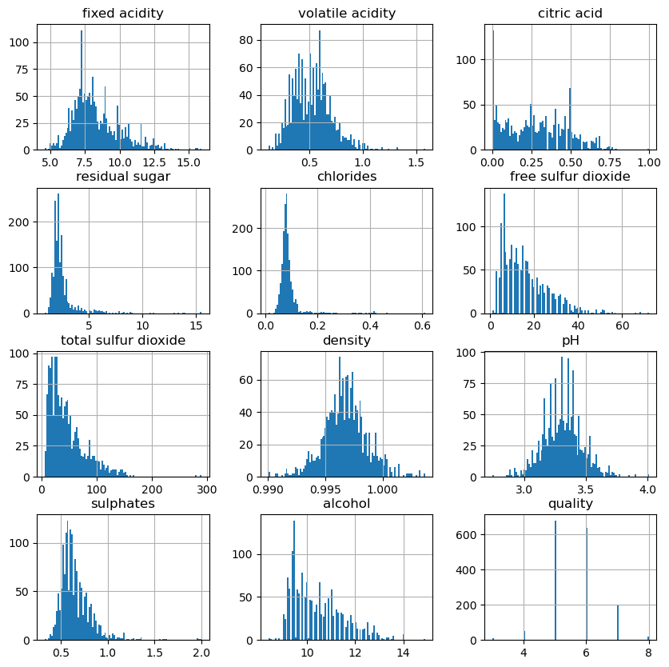

```python
ax =Data.hist(figsize= (10,10),bins = 100)
```

```
Note: predicted qualities are **unbalanced**
```

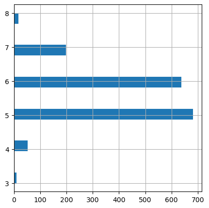

```python
ax =Data['quality'].hist(figsize= (5,5),orientation="horizontal",bins = 16)
print('Note: predicted qualities are **unbalanced** ')
```

## Lets reduce the number of classes to three: low, medium, high

```python
CodingQuality ={3:1,4:1,5:1,6:2,7:3,8:3}
Data['quality'] = Data['quality'].map(CodingQuality)
```

[output not shown]

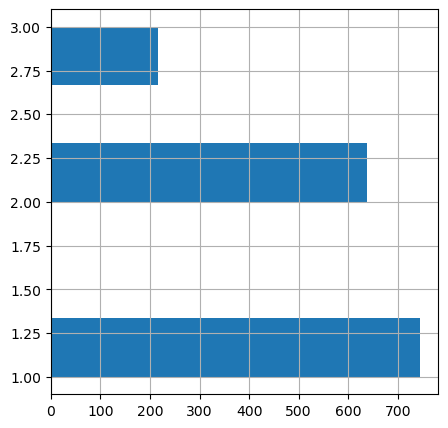

```python
ax =Data['quality'].hist(figsize= (5,5),orientation="horizontal",bins = 6)
print('Note: predicted qualities are almost balanced ')
```

### Scatter plot.

**Note that the class quality is coded with a color, i.e. c =Data['quality']**

```python
if False:
    ax = pd.plotting.scatter_matrix(Data,c =Data['quality'], figsize = (10,10))
```

[figure not shown]

## Partition database into train and test

Note the helper function

```python
def PartitionOfDatabase(Data,Fraction = 0.75):
    NumSamples, NumFeatures = Data.shape
    Index = list(range(NumSamples))
    RandomIndex = np.random.permutation(Index)
    NumTrainElements = int(Fraction*NumSamples)
    TrainIndex = RandomIndex[:NumTrainElements]
    TestIndex = RandomIndex[NumTrainElements:]
    TrainDB = Data.iloc[TrainIndex]
    TestDB = Data.iloc[TestIndex]
    return TrainDB,TestDB
TrainDB,TestDB = PartitionOfDatabase(Data,Fraction = 0.75)
```

```python
y = TrainDB['quality']
InputFeatures = [fea for fea in TrainDB.columns if  fea != 'quality']
print(f' Input variables: \n {InputFeatures}')
print('_'*50)
X = TrainDB[InputFeatures]
```

```
 Input variables:
 ['fixed acidity', 'volatile acidity', 'citric acid', 'residual sugar', 'chlorides', 'free sulfur dioxide', 'total sulfur dioxide', 'density', 'pH', 'sulphates', 'alcohol']
__________________________________________________
```

## Next we standarize the data, so that it has mean zero and standard deviation equal to one.

## $z = {(x - mean) \over std}$

### Important: Use the same scaler for the test database

```python
scaler = StandardScaler()
print(scaler.fit(X))
X =scaler.transform(X)
X = pd.DataFrame(data = X, columns = InputFeatures)
X.describe().round(2).T
print('** Important: Use the same scaler for the test database!**')
```

```
StandardScaler()
** Important: Use the same scaler for the test database!**
```

```python
X_test = TestDB[InputFeatures]
y_test = TestDB['quality']
X_test = scaler.transform(X_test)
X_test = pd.DataFrame(data = X_test, columns = InputFeatures)
print('Test database standardized with the training scaler.')
```

```
Test database standardized with the training scaler.
```

```python
Dimension_of_projection = 2
```

```python
lda = LinearDiscriminantAnalysis(n_components=Dimension_of_projection)
X_lda = lda.fit(X, y).transform(X)

X_lda = pd.DataFrame(data = X_lda, columns = ['dim1','dim2'])
```

```python
X_test_lda = lda.transform(X_test)
X_test_lda = pd.DataFrame(data = X_test_lda, columns = ['dim1','dim2'])
print('Test database projected with the same LDA model.')
```

```
Test database projected with the same LDA model.
```

### Homework: State briefly the criterion for deriving each method and the underlying hypothesis.

PCA chooses directions of maximum variance without using the labels, so its criterion is purely geometric. LDA/Fisher chooses directions that maximize the ratio of between-class scatter to within-class scatter, so it uses the class labels and assumes the classes are approximately Gaussian with a common covariance matrix.

### Homework: Given a multidimensional Gaussian with $x \in \mathbb{R}^p$, which is the distribution of a linear combination of the dimensions of $x$ ?

2. For a multivariate Gaussian, any linear combination of the coordinates is still Gaussian.

## Description of the projected elements

```python
X_lda.describe().round(2).T
```

|  | count | mean | std | min | 25% | 50% | 75% | max |
| --- | --- | --- | --- | --- | --- | --- | --- | --- |
| dim1 | 1199.0 | -0.0 | 1.29 | -5.3 | -0.99 | 0.15 | 1.01 | 3.24 |
| dim2 | 1199.0 | -0.0 | 1.01 | -7.8 | -0.54 | 0.06 | 0.70 | 2.60 |

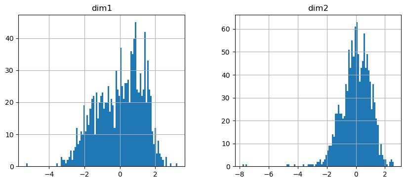

```python
ax = X_lda.hist(figsize = (10,4),bins = 100)
```

## Lets look into the space of the projection

$P(.):x \in \mathbb{R}^{11} \longrightarrow \mathbb{R}^2$

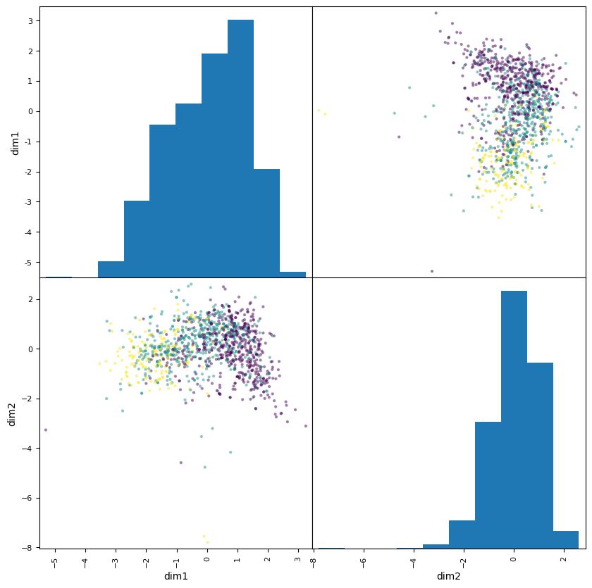

```python
ax = pd.plotting.scatter_matrix(X_lda,c =y, figsize = (10,10))
```

```python
lda.coef_[:1,:].shape
```

```
(1, 11)
```

```python
Coef_Lda = pd.DataFrame(data = lda.coef_[:2,:].T, columns = ['Proj class 1','Proj class 2'],index =X.columns.values)
Coef_Lda
```

|  | Proj class 1 | Proj class 2 |
| --- | --- | --- |
| fixed acidity | -0.238835 | 0.016374 |
| volatile acidity | 0.308210 | -0.199461 |
| citric acid | 0.093590 | -0.149150 |
| residual sugar | -0.077880 | -0.040063 |
| chlorides | 0.160816 | -0.066310 |
| free sulfur dioxide | -0.132458 | 0.151710 |
| total sulfur dioxide | 0.357739 | -0.269803 |
| density | 0.173124 | 0.068341 |
| pH | 0.018074 | -0.029749 |
| sulphates | -0.352432 | 0.141002 |
| alcohol | -0.571056 | 0.298794 |

```
Check what would have happened if we had not standarized.
```

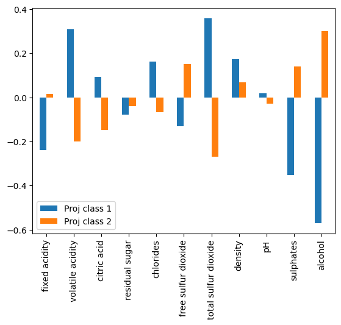

```python
ax =Coef_Lda.plot.bar()
print('Check what would have happened if we had not standarized.')
```

```python
print('Lets see how the means of each class compare to each other')
Means_Lda = pd.DataFrame(data = lda.means_.T, columns = ['Proj 1','Proj 2','Proj 3'],index =X.columns.values)
Means_Lda
```

```
Lets see how the means of each class compare to each other
```

|  | Proj 1 | Proj 2 | Proj 3 |
| --- | --- | --- | --- |
| fixed acidity | -0.113896 | 0.004000 | 0.355123 |
| volatile acidity | 0.352021 | -0.152971 | -0.693228 |
| citric acid | -0.175476 | -0.006421 | 0.583311 |
| residual sugar | 0.012986 | -0.056581 | 0.120909 |
| chlorides | 0.140099 | -0.077805 | -0.227224 |
| free sulfur dioxide | 0.097169 | -0.027844 | -0.232710 |
| total sulfur dioxide | 0.279378 | -0.185239 | -0.366599 |
| density | 0.176917 | -0.085965 | -0.322273 |
| pH | 0.002685 | 0.062546 | -0.188509 |
| sulphates | -0.259750 | 0.106350 | 0.530285 |
| alcohol | -0.493401 | 0.206234 | 0.995152 |

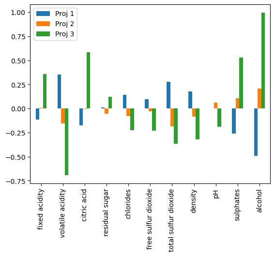

```python
ax =Means_Lda.plot.bar()
```

## Homework:

1. Comment on the meaning of the coefficients. What is the result of having different signs and sizes of the values?
2. If you have time, what would have happened if we had not standarized? What is the influence of the size/order of magnitude of the features?
3. What can you say about the means in the sense of separation between classes? Note that there seems to be like a continuity between the centers of mass for each quality.
1. The sign tells the direction of the effect and the magnitude tells how strongly a feature influences the discriminant score.
2. Because the features were standardized, the coefficients are comparable across variables; without standardization, variables with larger numeric scale would dominate only because of their units.
3. The strongest features are the ones tied to wine style and balance, especially alcohol, volatile acidity, sulphates, and sulfur dioxide. The class means move gradually from low quality to high quality rather than forming three completely separate clusters, so there is a clear continuity between the centers of mass for the three classes.

## Homework:

1. Create three logistic linear classifiers: Class 1 vs. {Class 2 and class 3}, Class 2 vs. {Class 1 and class 3}, Class 3 vs. {Class 1 and class 2} **Is there a difference between the performance on train and test?**
2. Do the classification on the original data, and on the data after the **lda** projection
3. From the coefficients of the lda and logistic linear classifiers, and the understanding of the problem, can you think of a feature engineering that might improve the problem
4. **Remember: the 'l2' option in the logistic classifier does a regularization function.**

```python
from IPython.display import display
from sklearn.linear_model import LogisticRegression
from sklearn.multiclass import OneVsRestClassifier


def one_vs_rest_summary(X_train, X_test, y_train, y_test):
    rows = []
    for cls in sorted(y_train.unique()):
        y_train_binary = (y_train == cls).astype(int)
        y_test_binary = (y_test == cls).astype(int)
        model = LogisticRegression(max_iter=2000, solver='liblinear', random_state=0)
        model.fit(X_train, y_train_binary)
        rows.append({
            'class': cls,
            'train_accuracy': accuracy_score(y_train_binary, model.predict(X_train)),
            'test_accuracy': accuracy_score(y_test_binary, model.predict(X_test))
        })
    return pd.DataFrame(rows)

original_results = one_vs_rest_summary(X, X_test, y, y_test)
lda_results = one_vs_rest_summary(X_lda, X_test_lda, y, y_test)

summary = pd.concat(
    [
        original_results.assign(space='original'),
        lda_results.assign(space='lda')
    ],
    ignore_index=True
)

print('One-vs-rest logistic regression accuracy by class and feature space:')
display(summary.pivot(index='class', columns='space', values=['train_accuracy', 'test_accuracy']).round(4))

overall_original = OneVsRestClassifier(LogisticRegression(max_iter=2000, solver='liblinear', random_state=0))
overall_original.fit(X, y)
overall_lda = OneVsRestClassifier(LogisticRegression(max_iter=2000, solver='liblinear', random_state=0))
overall_lda.fit(X_lda, y)

print(f'Overall OVR accuracy on original data: train={accuracy_score(y, overall_original.predict(X)):.4f}, test={accuracy_score(y_test, overall_original.predict(X_test)):.4f}')
print(f'Overall OVR accuracy on LDA projection: train={accuracy_score(y, overall_lda.predict(X_lda)):.4f}, test={accuracy_score(y_test, overall_lda.predict(X_test_lda)):.4f}')
print('Interpretation: train scores are slightly higher than test scores, and the original feature space is only marginally better than the 2D LDA projection.')
print('Feature-engineering idea: try interaction or ratio features such as alcohol/density, alcohol - volatile acidity, or alcohol*sulphates to capture the quality trend more directly.')
```

```
One-vs-rest logistic regression accuracy by class and feature space:
```

| space class | train_accuracy lda | train_accuracy original | test_accuracy lda | test_accuracy original |
| --- | --- | --- | --- | --- |
| 1 | 0.7623 | 0.7623 | 0.6925 | 0.6975 |
| 2 | 0.6097 | 0.6080 | 0.6075 | 0.6075 |
| 3 | 0.8757 | 0.8774 | 0.9000 | 0.8975 |

[output not shown]

## Description of variables: Wine quality

### Input variables (based on physicochemical tests):

1. fixed acidity
2. volatile acidity
3. citric acid
4. residual sugar
5. chlorides
6. free sulfur dioxide
7. total sulfur dioxide
8. density
9. pH
10. sulphates
11. alcohol Output variable (based on sensory data):
12. quality (score between 0 and 10)